# LMM: A showcase of some useful applications

2018-05-15

## Mixed-effects models

- 4.0 Introduction to LMM
- 4.1 Random effects
- 4.2 Solving LM problems using LMM
- 4.3 A showcase of some useful applications
- 4.4 Introduction to GLMM
- 4.5 More complex mixed models

## You will learn in this session

- how to estimate heritability
- how to perform phylogenetic regressions
- how to perform meta-analyses
- that mixed models can do a lot, but that they are a bit tedious

## Studying genetic variation using LMM

## The animal model

### Nothing but a simple LMM:

\[ y_i = \mu + a_i + e_i\]

with:

- \(\mu\) the population mean
- \(a_i\) the breeding value (i.e. the effects of the \(i\)'s genotype relative to \(\mu\))
- \(e_i\) a residual term.

The variance of the breeding values is the additive genetic variance \(V_\text{A}\).

The additive genetic covariance between two individuals = \(\text{A}V_\text{A}\), where \(\text{A}\) is the relatedness matrix.

## The relatedness matrix

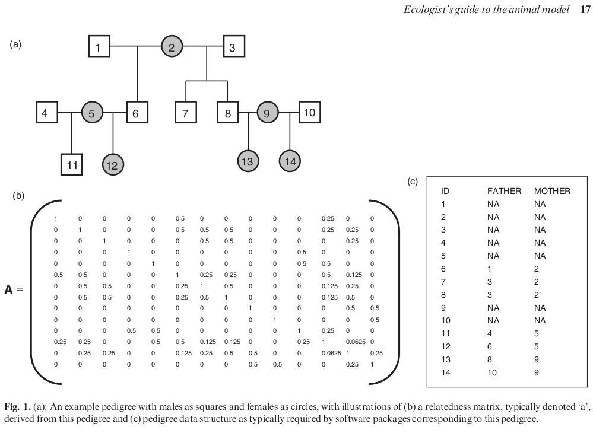

## The Gryphon dataset

[figure not shown]

[figure not shown]

## Building the matrix A

```r
tail(Gryphon$pedigree)
```

```
##       ID  Dam Sire
## 1304 127  917   NA
## 1305 117  550   NA
## 1306  95   29   NA
## 1307 158  689   NA
## 1308 131 1223   NA
## 1309 144 1222   NA
```

```r
library(nadiv)
A <- as(makeA(Gryphon$pedigree), "matrix")
colnames(A) <- rownames(A) <- Gryphon$pedigree$ID
A[1305:1309, 1296:1309]
```

```
##           113 130 155 100 145 133 90       110       127     117      95 158    131    144
## 117 0.0000000   0   0   0   0   0  0 0.0000000 0.0078125 1.00000 0.03125   0 0.0000 0.0000
## 95  0.0000000   0   0   0   0   0  0 0.0078125 0.0156250 0.03125 1.00000   0 0.0000 0.0000
## 158 0.0078125   0   0   0   0   0  0 0.0000000 0.0000000 0.00000 0.00000   1 0.0000 0.0000
## 131 0.0000000   0   0   0   0   0  0 0.0000000 0.0000000 0.00000 0.00000   0 1.0000 0.0625
## 144 0.0000000   0   0   0   0   0  0 0.0000000 0.0000000 0.00000 0.00000   0 0.0625 1.0000
```

## Fiting a simple Animal Model

```r
library(spaMM)
system.time(mod1 <- fitme(BWT ~ 1 + corrMatrix(1|ID), corrMatrix = A, data = Gryphon$data, method = "REML"))
```

```
##    user  system elapsed
##  54.872   4.339  59.661
```

```r
(h2 <- as.numeric(mod1$lambda / (mod1$lambda + mod1$phi)))
```

```
## [1] 0.4700152
```

## Fiting a more complex Animal Model

```r
Gryphon$data$sex    <- factor(Gryphon$data$SEX)
Gryphon$data$year   <- factor(Gryphon$data$BYEAR)
Gryphon$data$mother <- factor(Gryphon$data$MOTHER)

system.time(
  mod2 <- fitme(BWT ~ sex + (1|year) + (1|mother) + corrMatrix(1|ID), corrMatrix = A,
                data = Gryphon$data, method = "REML")
)
```

```
##    user  system elapsed
## 223.546  10.668 235.691
```

```r
h2 <- as.numeric(mod2$lambda["ID"]     / (sum(mod2$lambda) + mod2$phi))
m2 <- as.numeric(mod2$lambda["mother"] / (sum(mod2$lambda) + mod2$phi))

round(rbind("heritability" = h2, "maternal effect size" = m2), 3)
```

```
##                       [,1]
## heritability         0.388
## maternal effect size 0.189
```

## Predicting the breeding values (\(a_i\))

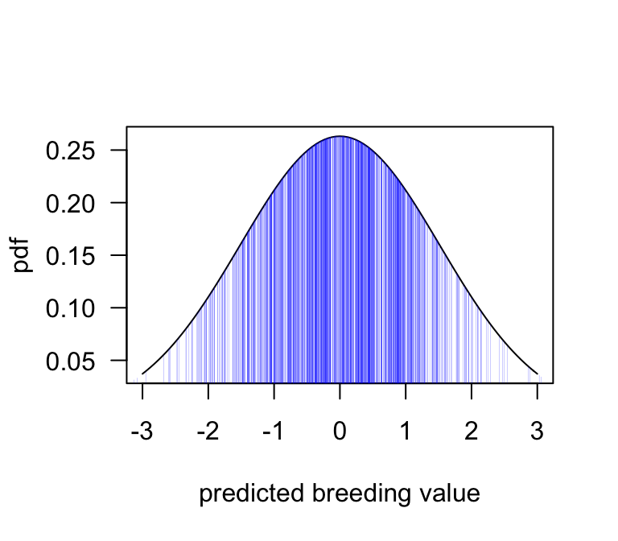

```r
curve(dnorm(x, sd = sqrt(as.numeric(mod2$lambda["ID"]))), from = -3, to = 3, las = 1,
      ylab = "pdf", xlab = "predicted breeding value")
BLUPs <- ranef(mod2)$"corrMatrix(1 | ID)"
points(dnorm(BLUPs, sd = sqrt(as.numeric(mod2$lambda["ID"]))) ~ BLUPs, col = "blue", type = "h", lwd = 0.1)
```

Never do statistics on BLUPs! Neglecting the uncertainty associated to these predictions is wrong.

Since BLUPs are here not added to fitted values, REML fit is the proper way to get them!

## Predicting the breeding values (\(a_i\))

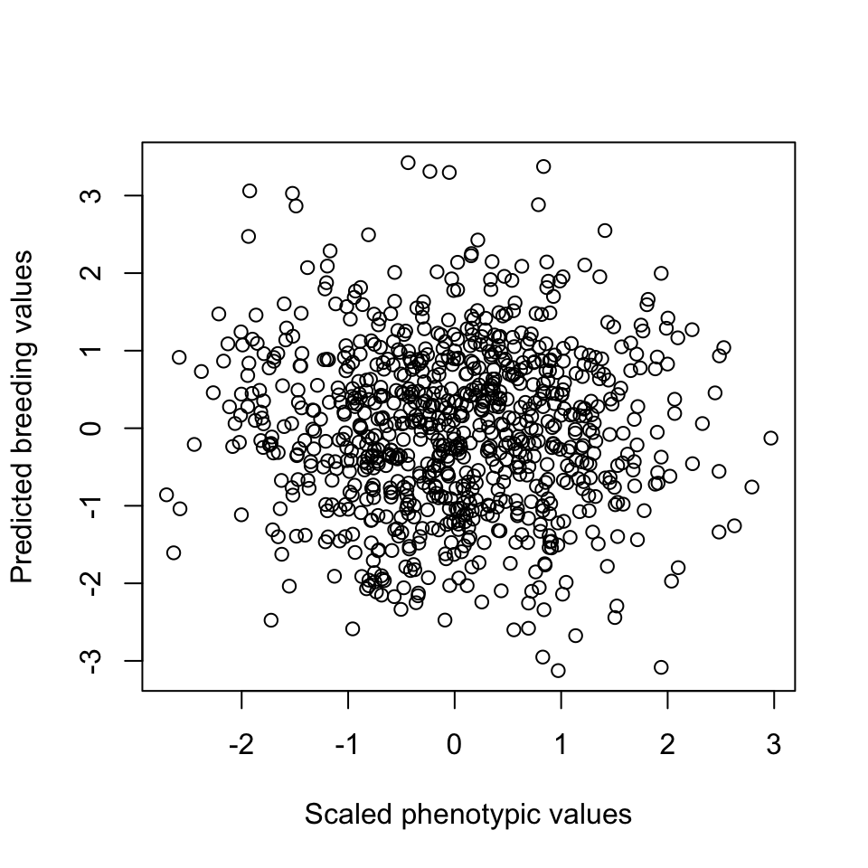

```r
plot(BLUPs ~ scale(mod2$data$BWT), ylab = "Predicted breeding values", xlab = "Scaled phenotypic values")
```

## Phylogenetic regressions

## The `ade4::carni70` dataset

```r
library(ade4)
data(carni70)
carni70$tab
```

```
##                            size range
## Puma_concolor             37.01 36.00
## Herpailurus_yaguaroundi    2.59 24.00
## Leopardus_wiedii           3.20 21.75
## Leopardus_pardalis         7.90 24.50
## Oreailurus_jacobita        3.99  1.75
## Oncifelis_colocolo         2.99  6.25
## Oncifelis_guigna           2.23  1.25
## Oncifelis_geoffroyi        3.80  4.75
## Leopardus_tigrinus         2.19 20.25
## Lynx_rufus                11.20 13.50
## Lynx_canadensis           10.10 15.50
## Panthera_onca             90.03 25.25
## Urocyon_cinereoargenteus   3.69 14.25
## Vulpes_velox               3.00  4.00
## Vulpes_vulpes              5.60 27.00
## Speothos_venaticus         6.00 16.50
## Chrysocyon_brachyurus     23.74  5.50
## Cerdocyon_thous            5.80 15.50
## Atelocynus_microtis        7.00  6.00
## Pseudalopex_vetulus        2.75  2.25
## Pseudalopex_sechurae       2.19  0.25
## Pseudalopex_gymnocercus    4.75  1.00
## Pseudalopex_griseus        3.90  3.75
## Pseudalopex_culpaeus       7.39  2.00
## Canis_latrans             12.75 27.00
## Canis_lupus               43.25 27.70
## Tremarctos_ornatus       199.98  1.50
## Ursus_americanus          77.50 17.75
## Ursus_arctos             266.50 16.75
## Potos_flavus               2.99 14.50
## Bassariscus_pauli          1.58  0.12
## Bassariscus_lasius         1.58  0.12
## Bassariscus_gabbii         1.25  0.75
## Bassariscus_beddardi       1.25  1.00
## Bassariscus_alleni         1.25  5.75
## Bassariscus_sumichrasti    1.05  1.25
## Bassariscus_astutus        0.92  6.00
## Nasuella_olivacea          1.38  0.50
## Nasua_nasua                4.05 19.75
```

[output cut: 16 more lines]

```
## Taxidea_taxus              7.65 12.25
## Lyncodon_patagonicus       1.05  0.75
## Galictis_vittata           3.20 17.75
## Galictis_cuja              1.60  5.50
## Eira_barbara               3.90 20.00
## Gulo_gulo                 20.75 15.00
## Martes_pennanti            3.37  5.50
## Martes_americana           0.63 16.75
## Mustela_vison              1.07 21.50
## Mustela_felipei            0.38  0.25
## Mustela_africana           0.22  5.25
## Mustela_nivalis            0.04 15.75
## Mustela_frenata            0.21 20.00
## Mustela_erminea            0.09 20.25
## Mustela_nigripes           0.51  3.50
```

## The phylogeny

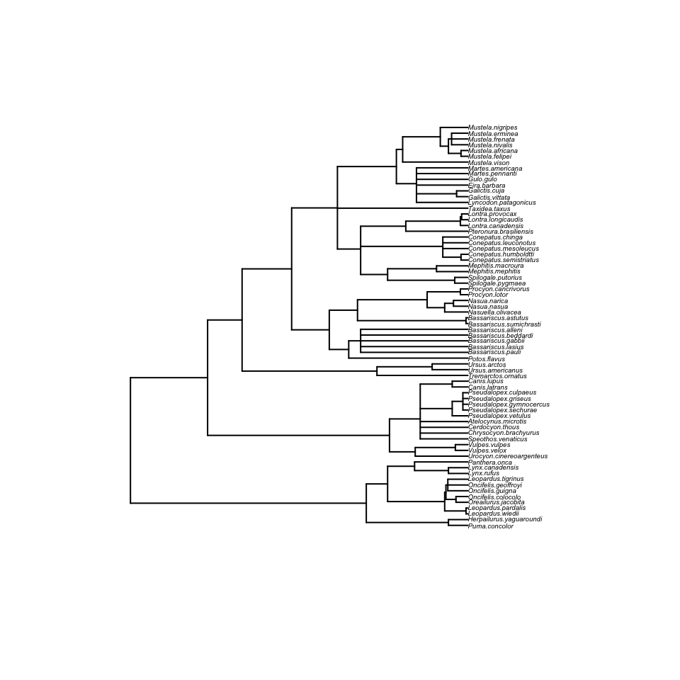

```r
library(ape)
tree <- read.tree(text = carni70$tre)
plot(tree, cex = 0.3)
```

## Turning a tree into a correlation matrix

```r
(corrM <- vcv(tree, model = "Brownian", corr = TRUE))
```

```
##                          Puma.concolor Herpailurus.yaguaroundi Leopardus.wiedii Leopardus.pardalis Oreailurus.jacobita
## Puma.concolor                1.0000000               0.9423792        0.6988848          0.6988848           0.6988848
## Herpailurus.yaguaroundi      0.9423792               1.0000000        0.6988848          0.6988848           0.6988848
## Leopardus.wiedii             0.6988848               0.6988848        1.0000000          0.9944238           0.9312268
## Leopardus.pardalis           0.6988848               0.6988848        0.9944238          1.0000000           0.9312268
## Oreailurus.jacobita          0.6988848               0.6988848        0.9312268          0.9312268           1.0000000
## Oncifelis.colocolo           0.6988848               0.6988848        0.9312268          0.9312268           0.9646840
## Oncifelis.guigna             0.6988848               0.6988848        0.9312268          0.9312268           0.9349442
## Oncifelis.geoffroyi          0.6988848               0.6988848        0.9312268          0.9312268           0.9349442
## Leopardus.tigrinus           0.6988848               0.6988848        0.9312268          0.9312268           0.9349442
## Lynx.rufus                   0.6988848               0.6988848        0.7620818          0.7620818           0.7620818
## Lynx.canadensis              0.6988848               0.6988848        0.7620818          0.7620818           0.7620818
## Panthera.onca                0.6988848               0.6988848        0.7620818          0.7620818           0.7620818
## Urocyon.cinereoargenteus     0.0000000               0.0000000        0.0000000          0.0000000           0.0000000
## Vulpes.velox                 0.0000000               0.0000000        0.0000000          0.0000000           0.0000000
##                          Oncifelis.colocolo Oncifelis.guigna Oncifelis.geoffroyi Leopardus.tigrinus Lynx.rufus
## Puma.concolor                     0.6988848        0.6988848           0.6988848          0.6988848  0.6988848
## Herpailurus.yaguaroundi           0.6988848        0.6988848           0.6988848          0.6988848  0.6988848
## Leopardus.wiedii                  0.9312268        0.9312268           0.9312268          0.9312268  0.7620818
## Leopardus.pardalis                0.9312268        0.9312268           0.9312268          0.9312268  0.7620818
## Oreailurus.jacobita               0.9646840        0.9349442           0.9349442          0.9349442  0.7620818
## Oncifelis.colocolo                1.0000000        0.9349442           0.9349442          0.9349442  0.7620818
## Oncifelis.guigna                  0.9349442        1.0000000           0.9405204          0.9405204  0.7620818
## Oncifelis.geoffroyi               0.9349442        0.9405204           1.0000000          0.9405204  0.7620818
## Leopardus.tigrinus                0.9349442        0.9405204           0.9405204          1.0000000  0.7620818
## Lynx.rufus                        0.7620818        0.7620818           0.7620818          0.7620818  1.0000000
## Lynx.canadensis                   0.7620818        0.7620818           0.7620818          0.7620818  0.9423792
## Panthera.onca                     0.7620818        0.7620818           0.7620818          0.7620818  0.8420074
## Urocyon.cinereoargenteus          0.0000000        0.0000000           0.0000000          0.0000000  0.0000000
## Vulpes.velox                      0.0000000        0.0000000           0.0000000          0.0000000  0.0000000
##                          Lynx.canadensis Panthera.onca Urocyon.cinereoargenteus Vulpes.velox Vulpes.vulpes
## Puma.concolor                  0.6988848     0.6988848                0.0000000    0.0000000     0.0000000
## Herpailurus.yaguaroundi        0.6988848     0.6988848                0.0000000    0.0000000     0.0000000
## Leopardus.wiedii               0.7620818     0.7620818                0.0000000    0.0000000     0.0000000
## Leopardus.pardalis             0.7620818     0.7620818                0.0000000    0.0000000     0.0000000
## Oreailurus.jacobita            0.7620818     0.7620818                0.0000000    0.0000000     0.0000000
## Oncifelis.colocolo             0.7620818     0.7620818                0.0000000    0.0000000     0.0000000
## Oncifelis.guigna               0.7620818     0.7620818                0.0000000    0.0000000     0.0000000
## Oncifelis.geoffroyi            0.7620818     0.7620818                0.0000000    0.0000000     0.0000000
## Leopardus.tigrinus             0.7620818     0.7620818                0.0000000    0.0000000     0.0000000
```

[output cut: 171 more lines]

```
## Puma.concolor                  0.0000000       0.0000000        0.0000000
## Herpailurus.yaguaroundi        0.0000000       0.0000000        0.0000000
## Leopardus.wiedii               0.0000000       0.0000000        0.0000000
## Leopardus.pardalis             0.0000000       0.0000000        0.0000000
## Oreailurus.jacobita            0.0000000       0.0000000        0.0000000
## Oncifelis.colocolo             0.0000000       0.0000000        0.0000000
## Oncifelis.guigna               0.0000000       0.0000000        0.0000000
## Oncifelis.geoffroyi            0.0000000       0.0000000        0.0000000
## Leopardus.tigrinus             0.0000000       0.0000000        0.0000000
## Lynx.rufus                     0.0000000       0.0000000        0.0000000
## Lynx.canadensis                0.0000000       0.0000000        0.0000000
## Panthera.onca                  0.0000000       0.0000000        0.0000000
## Urocyon.cinereoargenteus       0.2286245       0.2286245        0.2286245
## Vulpes.velox                   0.2286245       0.2286245        0.2286245
##  [ reached getOption("max.print") -- omitted 56 rows ]
```

## Fitting the phylogenetic regression model

```r
carni70$tab$sp <- factor(rownames(corrM))
(mod_carni <- fitme(range ~ size + corrMatrix(1|sp), corrMatrix = corrM, data = carni70$tab))
```

```
## formula: range ~ size + corrMatrix(1 | sp)
## ML: Estimation of lambda and phi by ML.
##     Estimation of fixed effects by ML.
## Family: gaussian ( link = identity )
##  ------------ Fixed effects (beta) ------------
##             Estimate Cond. SE t-value
## (Intercept) 11.13290  2.31832   4.802
## size         0.03236  0.02804   1.154
##  --------------- Random effects ---------------
## Family: gaussian ( link = identity )
##            --- Variance parameters ('lambda'):
## lambda = var(u) for u ~ Gaussian;
##    sp  :  13.34
##              --- Coefficients for log(lambda):
##  Group        Term Estimate Cond.SE
##     sp (Intercept)    2.591  0.6018
## # of obs: 70; # of groups: sp, 70
##  ------------- Residual variance  -------------
## Coefficients for log(phi) ~ 1 :
##             Estimate Cond. SE
## (Intercept)    4.281   0.1761
## Estimate of phi=residual var:  72.32
##  ------------- Likelihood values  -------------
##                         logLik
## p_v(h) (marginal L): -252.9773
```

## Testing the fixed effects

```r
mod_carni_no_size <- fitme(range ~ 1 + corrMatrix(1|sp), corrMatrix = corrM, data = carni70$tab)
anova(mod_carni, mod_carni_no_size)
```

```
##      chi2_LR df   p_value
## p_v 1.316902  1 0.2511488
```

## Comparison with the traditional `gls` fit

```r
library(nlme)
rownames(carni70$tab) <- rownames(corrM)
(mod_carni2 <- gls(range ~ size, correlation = corBrownian(1, phy = tree), method = "ML", data = carni70$tab))
```

```
## Generalized least squares fit by maximum likelihood
##   Model: range ~ size
##   Data: carni70$tab
##   Log-likelihood: -264.5214
##
## Coefficients:
## (Intercept)        size
## 11.91760790  0.04856416
##
## Correlation Structure: corBrownian
##  Formula: ~1
##  Parameter estimate(s):
## numeric(0)
## Degrees of freedom: 70 total; 68 residual
## Residual standard error: 26.8213
```

A benefit of using a proper (G)LMM instead of the Generalized Least Squares is that we could also consider other random effects and model a non gaussian response (GLMM). The function `fitme()` does that, but `gls()` cannot.

## Comparison with the traditional `gls` fit

```r
mod_carni2_no_size <- gls(range ~ 1, correlation = corBrownian(1, tree), method = "ML", data = carni70$tab)
anova(mod_carni2, mod_carni2_no_size)
```

```
##                    Model df      AIC      BIC    logLik   Test   L.Ratio p-value
## mod_carni2             1  3 535.0427 541.7882 -264.5214
## mod_carni2_no_size     2  2 533.9469 538.4439 -264.9734 1 vs 2 0.9041323  0.3417
```

Note: differences between LMM and GLS are expected.

## Meta-analyses

## Example: The `metafor::dat.bcg` dataset

### Studies on the effectiveness of the BCG vaccine against Tuberculosis

```r
library(metafor)
dat.bcg
```

```
##    trial               author year tpos  tneg cpos  cneg ablat      alloc
## 1      1              Aronson 1948    4   119   11   128    44     random
## 2      2     Ferguson & Simes 1949    6   300   29   274    55     random
## 3      3      Rosenthal et al 1960    3   228   11   209    42     random
## 4      4    Hart & Sutherland 1977   62 13536  248 12619    52     random
## 5      5 Frimodt-Moller et al 1973   33  5036   47  5761    13  alternate
## 6      6      Stein & Aronson 1953  180  1361  372  1079    44  alternate
## 7      7     Vandiviere et al 1973    8  2537   10   619    19     random
## 8      8           TPT Madras 1980  505 87886  499 87892    13     random
## 9      9     Coetzee & Berjak 1968   29  7470   45  7232    27     random
## 10    10      Rosenthal et al 1961   17  1699   65  1600    42 systematic
## 11    11       Comstock et al 1974  186 50448  141 27197    18 systematic
## 12    12   Comstock & Webster 1969    5  2493    3  2338    33 systematic
## 13    13       Comstock et al 1976   27 16886   29 17825    33 systematic
```

## We compute an effect size

### Let's compute the relative risks and associated sampling variances:

```r
dat.bcg$RR  <- with(dat.bcg, log((tpos/(tpos + tneg)) / (cpos/(cpos + cneg))))
dat.bcg$sampling.var <- with(dat.bcg, 1/tpos - 1/tneg + 1/cpos - 1/cneg)
dat.bcg
```

```
##    trial               author year tpos  tneg cpos  cneg ablat      alloc          RR sampling.var
## 1      1              Aronson 1948    4   119   11   128    44     random -0.88931133   0.32469323
## 2      2     Ferguson & Simes 1949    6   300   29   274    55     random -1.58538866   0.19416646
## 3      3      Rosenthal et al 1960    3   228   11   209    42     random -1.34807315   0.41507177
## 4      4    Hart & Sutherland 1977   62 13536  248 12619    52     random -1.44155119   0.02000817
## 5      5 Frimodt-Moller et al 1973   33  5036   47  5761    13  alternate -0.21754732   0.05120747
## 6      6      Stein & Aronson 1953  180  1361  372  1079    44  alternate -0.78611559   0.00658219
## 7      7     Vandiviere et al 1973    8  2537   10   619    19     random -1.62089822   0.22299032
## 8      8           TPT Madras 1980  505 87886  499 87892    13     random  0.01195233   0.00396145
## 9      9     Coetzee & Berjak 1968   29  7470   45  7232    27     random -0.46941765   0.05643284
## 10    10      Rosenthal et al 1961   17  1699   65  1600    42 systematic -1.37134480   0.07299456
## 11    11       Comstock et al 1974  186 50448  141 27197    18 systematic -0.33935883   0.01241195
## 12    12   Comstock & Webster 1969    5  2493    3  2338    33 systematic  0.44591340   0.53250449
## 13    13       Comstock et al 1976   27 16886   29 17825    33 systematic -0.01731395   0.07140447
```

## We fit the model with `metafor`

```r
(mod <- rma(yi = RR ~ factor(alloc) + year + ablat, vi = sampling.var, data = dat.bcg, method = "REML"))
```

```
##
## Mixed-Effects Model (k = 13; tau^2 estimator: REML)
##
## tau^2 (estimated amount of residual heterogeneity):     0.1796 (SE = 0.1425)
## tau (square root of estimated tau^2 value):             0.4238
## I^2 (residual heterogeneity / unaccounted variability): 73.11%
## H^2 (unaccounted variability / sampling variability):   3.72
## R^2 (amount of heterogeneity accounted for):            42.67%
##
## Test for Residual Heterogeneity:
## QE(df = 8) = 26.2249, p-val = 0.0010
##
## Test of Moderators (coefficient(s) 2:5):
## QM(df = 4) = 9.5287, p-val = 0.0492
##
## Model Results:
##
##                          estimate       se     zval    pval     ci.lb    ci.ub
## intrcpt                  -14.4802  38.3822  -0.3773  0.7060  -89.7081  60.7476
## factor(alloc)random       -0.3421   0.4178  -0.8188  0.4129   -1.1610   0.4768
## factor(alloc)systematic    0.0100   0.4466   0.0224  0.9821   -0.8652   0.8853
## year                       0.0075   0.0194   0.3845  0.7006   -0.0306   0.0456
## ablat                     -0.0236   0.0132  -1.7819  0.0748   -0.0495   0.0024  .
##
## ---
## Signif. codes:  0 '***' 0.001 '**' 0.01 '*' 0.05 '.' 0.1 ' ' 1
```

## We fit the model with `spaMM`

```r
dat.bcg$study <- factor(dat.bcg$trial)
(mod_spaMM <- fitme(RR ~ factor(alloc) + year + ablat + (1|study), data = dat.bcg,
                    fixed = list(phi = dat.bcg$sampling.var), method = "REML"))
```

```
## formula: RR ~ factor(alloc) + year + ablat + (1 | study)
## REML: Estimation of lambda by REML.
##       Estimation of fixed effects by ML.
## Family: gaussian ( link = identity )
##  ------------ Fixed effects (beta) ------------
##                           Estimate Cond. SE  t-value
## (Intercept)             -14.480233 38.38236 -0.37726
## factor(alloc)random      -0.342085  0.41781 -0.81875
## factor(alloc)systematic   0.010015  0.44657  0.02243
## year                      0.007471  0.01943  0.38454
## ablat                    -0.023559  0.01322 -1.78190
##  --------------- Random effects ---------------
## Family: gaussian ( link = identity )
##            --- Variance parameters ('lambda'):
## lambda = var(u) for u ~ Gaussian;
##    study  :  0.1796
##              --- Coefficients for log(lambda):
##  Group        Term Estimate Cond.SE
##  study (Intercept)   -1.717  0.6505
## # of obs: 13; # of groups: study, 13
##  ------------- Residual variance  -------------
## phi was fixed.
##  ------------- Likelihood values  -------------
##                          logLik
## p_v(h) (marginal L):  -8.276558
##   p_beta,v(h) (ReL): -16.279925
```

## Comparing outputs

```r
round(c(tau2_metafor = mod$tau2, lambda_spaMM = mod_spaMM$lambda[[1]]), 4)  ## heterogeneity between studies
```

```
## tau2_metafor lambda_spaMM
##       0.1796       0.1796
```

```r
mod_spaMMRE <- fitme(RR ~ 1 + (1|study), data = dat.bcg,
                     fixed = list(phi = dat.bcg$sampling.var), method = "REML")

R2_spaMM <- 100 * (mod_spaMMRE$lambda[[1]] - mod_spaMM$lambda[[1]]) / mod_spaMMRE$lambda[[1]]
round(c(R2_metafor = mod$R2, R2_spaMM = R2_spaMM), 4)  ## amount of heterogeneity accounted for by fixed effects
```

```
## R2_metafor   R2_spaMM
##    42.6746    42.6747
```

## Comparing outputs

```r
c(mod$I2, mod$H2, mod$QE) ## from metafor, see ?print.rma.uni for details
```

```
## [1] 73.112215  3.719161 26.224912
```

```r
get_meta_metrics <- function(model, vi) {
  wi <- 1/vi  ## weights = inverse of sampling variance
  k <- length(model$ranef)  ## number of groups in random term (here number of studies)
  p <- length(model$fixef)  ## number of fixed effect parameters
  W <- diag(wi, nrow = k, ncol = k)  ## matrix of weights
  X <- as.matrix(as.data.frame(model$X.pv))  ## design matrix
  stXWX <- solve(t(X) %*% W %*% X)  ## weighted vcov of estimates
  P <- W - W %*% X %*% stXWX %*% crossprod(X, W)  ## weighted vcov of ??
  vi.avg <- (k - p) / sum(diag(P))
  I2 <- as.numeric(100 * model$lambda / (vi.avg + model$lambda) )
  H2 <- as.numeric((vi.avg + model$lambda) / vi.avg)
  QE <- max(0, c(crossprod(model$y, P) %*% model$y))
  return(c(I2 = I2, H2 = H2, QE = QE, vi.avg = vi.avg))
}

get_meta_metrics(mod_spaMM, dat.bcg$sampling.var) ## add vi.avg: weighted mean within study sampling variance
```

```
##          I2          H2          QE      vi.avg
## 73.11221383  3.71916079 26.22491189  0.06603711
```

## Nice plots with `metafor`

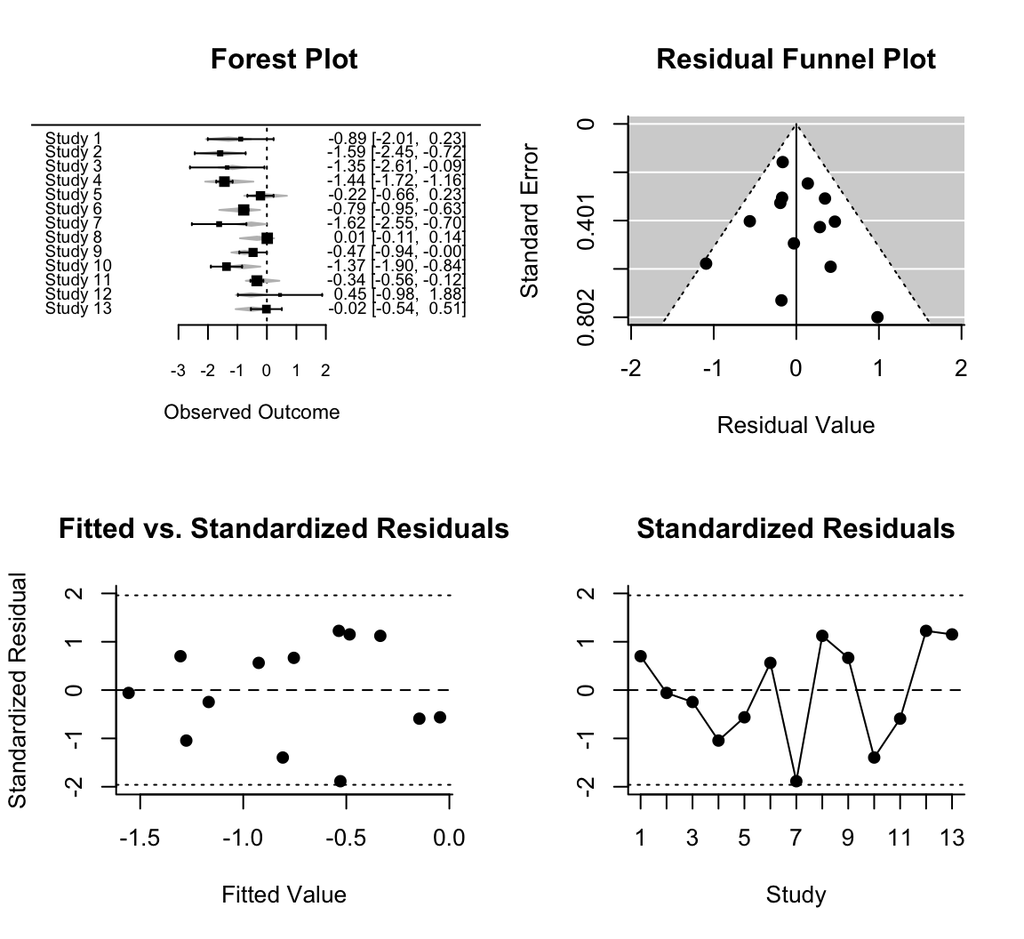

```r
metafor::plot.rma.uni(mod)  ## or just plot(mod)
```

## Can we do abstraction of fixed effects?

```r
mod_spaMM2    <- fitme(RR ~ factor(alloc) + year + ablat + (1|study), data = dat.bcg,
                       fixed = list(phi = dat.bcg$sampling.var))
mod_spaMM2_H0 <- fitme(RR ~ 1 + (1|study), data = dat.bcg, fixed = list(phi = dat.bcg$sampling.var))
anova(mod_spaMM2, mod_spaMM2_H0)
```

```
##      chi2_LR df    p_value
## p_v 11.49504  4 0.02152916
```

## Can we do abstraction of fixed effects?

```r
res.boot <- anova(mod_spaMM2, mod_spaMM2_H0, boot.repl = 1000)
```

```
## Bootstrap replicates: bootstrap took 125.4 s.
```

## Can we do abstraction of fixed effects?

```r
res.boot
```

```
##      chi2_LR df    p_value
## p_v 11.49504  4 0.02152916
##  ======== Bootstrap: ========
## Raw simulated p-value: 0.188
## Bartlett-corrected LR test:
##      chi2_LR df  p_value
## p_v 6.564475  4 0.160773
```

## Can we do abstraction of fixed effects?

```r
(mod2 <- rma(yi = RR ~ factor(alloc) + year + ablat, vi = sampling.var, data = dat.bcg, method = "ML"))
```

```
##
## Mixed-Effects Model (k = 13; tau^2 estimator: ML)
##
## tau^2 (estimated amount of residual heterogeneity):     0.0328 (SE = 0.0271)
## tau (square root of estimated tau^2 value):             0.1812
## I^2 (residual heterogeneity / unaccounted variability): 33.20%
## H^2 (unaccounted variability / sampling variability):   1.50
## R^2 (amount of heterogeneity accounted for):            88.28%
##
## Test for Residual Heterogeneity:
## QE(df = 8) = 26.2249, p-val = 0.0010
##
## Test of Moderators (coefficient(s) 2:5):
## QM(df = 4) = 31.3322, p-val < .0001
##
## Model Results:
##
##                          estimate       se     zval    pval     ci.lb    ci.ub
## intrcpt                  -10.0373  23.9712  -0.4187  0.6754  -57.0200  36.9454
## factor(alloc)random       -0.2830   0.2536  -1.1160  0.2644   -0.7799   0.2140
## factor(alloc)systematic   -0.1112   0.2547  -0.4366  0.6624   -0.6103   0.3879
## year                       0.0053   0.0122   0.4358  0.6630   -0.0185   0.0291
## ablat                     -0.0277   0.0071  -3.9346  <.0001   -0.0416  -0.0139  ***
##
## ---
## Signif. codes:  0 '***' 0.001 '**' 0.01 '*' 0.05 '.' 0.1 ' ' 1
```

## Can we do abstraction of fixed effects?

```r
(mod3 <- rma(yi = RR ~ factor(alloc) + year + ablat, vi = sampling.var, data = dat.bcg, method = "ML",
             test = "knha"))
```

```
##
## Mixed-Effects Model (k = 13; tau^2 estimator: ML)
##
## tau^2 (estimated amount of residual heterogeneity):     0.0328 (SE = 0.0271)
## tau (square root of estimated tau^2 value):             0.1812
## I^2 (residual heterogeneity / unaccounted variability): 33.20%
## H^2 (unaccounted variability / sampling variability):   1.50
## R^2 (amount of heterogeneity accounted for):            88.28%
##
## Test for Residual Heterogeneity:
## QE(df = 8) = 26.2249, p-val = 0.0010
##
## Test of Moderators (coefficient(s) 2:5):
## F(df1 = 4, df2 = 8) = 3.6513, p-val = 0.0562
##
## Model Results:
##
##                          estimate       se     tval    pval     ci.lb    ci.ub
## intrcpt                  -10.0373  35.1102  -0.2859  0.7822  -91.0014  70.9269
## factor(alloc)random       -0.2830   0.3714  -0.7619  0.4680   -1.1394   0.5734
## factor(alloc)systematic   -0.1112   0.3730  -0.2981  0.7732   -0.9713   0.7489
## year                       0.0053   0.0178   0.2975  0.7737   -0.0358   0.0464
## ablat                     -0.0277   0.0103  -2.6863  0.0277   -0.0516  -0.0039  *
##
## ---
## Signif. codes:  0 '***' 0.001 '**' 0.01 '*' 0.05 '.' 0.1 ' ' 1
```

## Does vaccination work?

```r
mod_spaMM3    <- fitme(RR ~ 1 + (1|study), data = dat.bcg, fixed = list(phi = dat.bcg$sampling.var))
mod_spaMM3_H0 <- fitme(RR ~ 0 + (1|study), data = dat.bcg, fixed = list(phi = dat.bcg$sampling.var))
anova(mod_spaMM3, mod_spaMM3_H0)
```

```
##      chi2_LR df     p_value
## p_v 11.10583  1 0.000860566
```

## Does vaccination work?

```r
res.boot2 <- anova(mod_spaMM3, mod_spaMM3_H0, boot.repl = 1000)
```

```
## Bootstrap replicates: bootstrap took 58.5 s.
```

## Does vaccination work?

```r
res.boot2
```

```
##      chi2_LR df     p_value
## p_v 11.10583  1 0.000860566
##  ======== Bootstrap: ========
## Raw simulated p-value: 0.002
## Bartlett-corrected LR test:
##      chi2_LR df     p_value
## p_v 10.54822  1 0.001162999
```

## Does vaccination work?

```r
mod_spaMM3$fixef
```

```
## (Intercept)
##  -0.7112869
```

```r
get_intervals(mod_spaMM3, re.form = NA, intervals = "predVar")[1, ]
```

```
## predVar_0.025 predVar_0.975
##    -1.0481514    -0.3744224
```

## Does vaccination work?

```r
(mod4 <- rma(yi = RR ~ 1, vi = sampling.var, data = dat.bcg, method = "ML"))
```

```
##
## Random-Effects Model (k = 13; tau^2 estimator: ML)
##
## tau^2 (estimated amount of total heterogeneity): 0.2800 (SE = 0.1442)
## tau (square root of estimated tau^2 value):      0.5292
## I^2 (total heterogeneity / total variability):   91.47%
## H^2 (total variability / sampling variability):  11.73
##
## Test for Heterogeneity:
## Q(df = 12) = 153.1534, p-val < .0001
##
## Model Results:
##
## estimate      se     zval    pval    ci.lb    ci.ub
##  -0.7113  0.1719  -4.1385  <.0001  -1.0482  -0.3744  ***
##
## ---
## Signif. codes:  0 '***' 0.001 '**' 0.01 '*' 0.05 '.' 0.1 ' ' 1
```

## Does vaccination work?

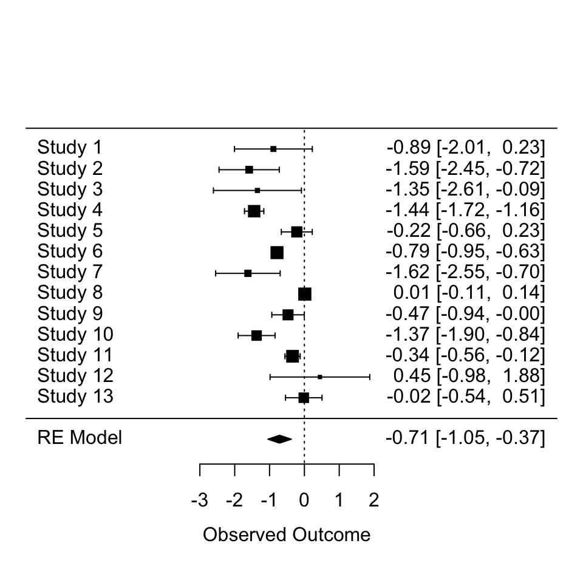

```r
forest(mod4)
```

## What you need to remember

- that mixed models can do a lot, but that they are a bit tedious

## Table of contents

## Mixed-effects models

- 4.0 Introduction to LMM
- 4.1 Random effects
- 4.2 Solving LM problems using LMM
- 4.3 A showcase of some useful applications
- 4.4 Introduction to GLMM
- 4.5 More complex mixed models